R语言大作业 金小龙 吴大宇 车联网数据分析

# Data1 Analysis

Wu Dayu(PB19030934) and Jin Xiaolong(PB19000314)

Project background: In recent years, with the rapid development of Internet of Vehicles technology, people can carry out statistical analysis of drivers' driving behaviors-including driving habits analysis, driver driving behavior portraits, and can also provide early warning of drivers' bad driving behaviors.

The data used comes from a website, contains 8 vehicle information, divided into 754 segments. During driving, data is recorded every second or every 15 seconds. The data contains 14 indicators (all continuous), divided into 5 dimensions: time dimension, speed dimension, mileage dimension, mechanical dimension, driving stability.

- Time dimension: driving time, fatigue driving time, morning and evening rush hours, night drive
- Average speed, maximum speed, speed standard deviation, congestion, high speed drive
- Mileage dimension: mileage
- Mechanical performance: average engine speed, maximum engine speed, standard deviation of engine speed
- Driving stability: stability

## Data preprocessing

```python
# import package
import pandas as pd
import numpy as np
import matplotlib.pyplot as plt

# load data
df2 = pd.read_csv("data2.csv")

# Sort vehicle data by category
df2_car1 = df2[df2['NUM']==1]
df2_car2 = df2[df2['NUM']==2]
df2_car3 = df2[df2['NUM']==3]
df2_car4 = df2[df2['NUM']==4]
df2_car5 = df2[df2['NUM']==5]
df2_car6 = df2[df2['NUM']==6]
df2_car7 = df2[df2['NUM']==7]
df2_car8 = df2[df2['NUM']==8]

# Data preprocessing
del df2_car1['NUM']
del df2_car2['NUM']
del df2_car3['NUM']
del df2_car4['NUM']
del df2_car5['NUM']
del df2_car6['NUM']
del df2_car7['NUM']
del df2_car8['NUM']
```

## Data Analysis of Car 1

|  | DIST | DRVTIME | SPEED_AVG | SPEED_SD | SPEED_MAX | STAB | WHEEL_AVG | WHEEL_SD | WHEEL_MAX | RUSHOUR | NIGHT | JAM | HIGHSPEED | TIRED |
| --- | --- | --- | --- | --- | --- | --- | --- | --- | --- | --- | --- | --- | --- | --- |
| count | 63.000000 | 63.000000 | 63.000000 | 63.000000 | 63.000000 | 63.000000 | 63.000000 | 63.000000 | 63.000000 | 63.000000 | 63.000000 | 63.000000 | 63.000000 | 63.000000 |
| mean | 20.983333 | 0.543126 | 21.253840 | 16.847632 | 58.714286 | 1.022835 | 1091.250559 | 322.958098 | 1962.285714 | 0.298195 | 0.017543 | 0.514502 | 0.055483 | 0.083576 |
| std | 45.008643 | 0.626046 | 20.572461 | 10.020135 | 32.942486 | 0.170095 | 251.250934 | 98.996130 | 482.412065 | 0.433155 | 0.109568 | 0.219776 | 0.150212 | 0.471747 |
| min | 0.050000 | 0.056942 | 0.700000 | 2.344661 | 12.000000 | 0.188973 | 746.350000 | 113.591159 | 1238.000000 | 0.000000 | 0.000000 | 0.063380 | 0.000000 | 0.000000 |
| 25% | 1.000000 | 0.140834 | 10.340323 | 11.168003 | 39.000000 | 0.973544 | 956.738636 | 273.111781 | 1619.000000 | 0.000000 | 0.000000 | 0.357822 | 0.000000 | 0.000000 |
| 50% | 2.000000 | 0.278333 | 13.026578 | 13.148688 | 45.000000 | 1.056187 | 1008.306154 | 304.478935 | 1792.000000 | 0.000000 | 0.000000 | 0.557692 | 0.000000 | 0.000000 |
| 75% | 13.000000 | 0.700834 | 22.726400 | 18.299235 | 65.000000 | 1.101829 | 1147.605901 | 341.003174 | 2290.500000 | 0.782414 | 0.000000 | 0.659946 | 0.000000 | 0.000000 |
| max | 184.000000 | 3.066389 | 85.727707 | 46.897023 | 144.000000 | 1.218076 | 1867.327229 | 623.358663 | 3093.000000 | 1.000000 | 0.829167 | 1.000000 | 0.619427 | 3.066389 |

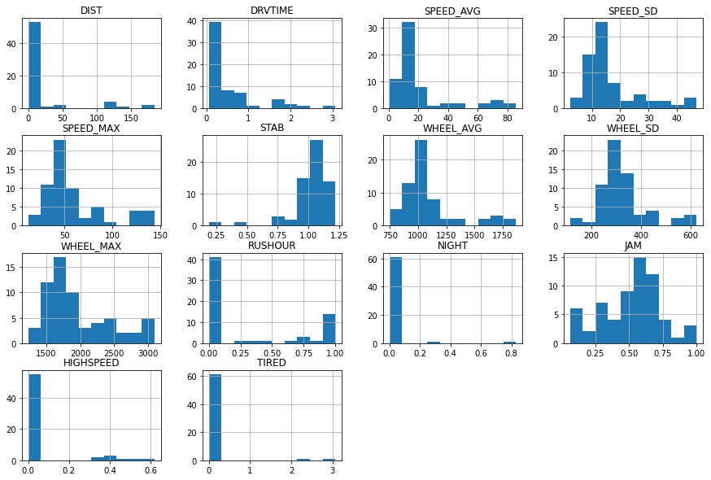

```python
# Descriptive statistics
df2_car1.hist(figsize=(15,10))
df2_car1.describe()
```

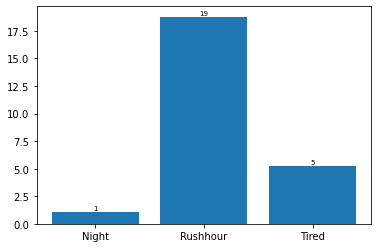

```python
# Fatigue driving time, morning and evening peak hours, and late night travel time ratio
df2_car1.sum()
ylabel = [df2_car1.sum()["NIGHT"],df2_car1.sum()["RUSHOUR"],df2_car1.sum()["TIRED"]]
xlabel = ["Night" , "Rushhour" , "Tired"]
plt.bar(xlabel , ylabel)

for a,b in zip(xlabel,ylabel):
    plt.text(a, b+0.05, '%.0f' % b, ha='center', va= 'bottom',fontsize=7)

plt.show()
```

## Data Analysis of Car 2

|  | DIST | DRVTIME | SPEED_AVG | SPEED_SD | SPEED_MAX | STAB | WHEEL_AVG | WHEEL_SD | WHEEL_MAX | RUSHOUR | NIGHT | JAM | HIGHSPEED | TIRED |
| --- | --- | --- | --- | --- | --- | --- | --- | --- | --- | --- | --- | --- | --- | --- |
| count | 90.000000 | 90.000000 | 90.000000 | 90.000000 | 90.000000 | 90.000000 | 90.000000 | 90.000000 | 90.000000 | 90.00000 | 90.000000 | 90.000000 | 90.000000 | 90.000000 |
| mean | 22.904667 | 0.792318 | 27.743238 | 21.330662 | 76.255556 | 1.015761 | 1263.983558 | 431.672179 | 2549.266667 | 0.15825 | 0.147951 | 0.398908 | 0.014609 | 0.199481 |
| std | 34.353890 | 0.700741 | 13.846343 | 7.132505 | 26.105904 | 0.141679 | 191.748289 | 69.089247 | 540.393777 | 0.34235 | 0.350148 | 0.179100 | 0.065455 | 0.704661 |
| min | 0.050000 | 0.058610 | 4.000000 | 4.370466 | 18.000000 | 0.434853 | 808.022222 | 165.646642 | 1377.000000 | 0.00000 | 0.000000 | 0.072848 | 0.000000 | 0.000000 |
| 25% | 5.000000 | 0.294097 | 16.607350 | 16.135201 | 56.250000 | 0.996285 | 1161.051314 | 403.681391 | 2323.500000 | 0.00000 | 0.000000 | 0.274925 | 0.000000 | 0.000000 |
| 50% | 15.000000 | 0.570139 | 26.449995 | 22.654862 | 78.000000 | 1.069785 | 1251.349356 | 432.283710 | 2495.000000 | 0.00000 | 0.000000 | 0.388990 | 0.000000 | 0.000000 |
| 75% | 32.750000 | 1.091112 | 37.637387 | 26.118547 | 93.750000 | 1.103000 | 1375.981153 | 464.686366 | 2707.250000 | 0.00000 | 0.000000 | 0.496955 | 0.003755 | 0.000000 |
| max | 301.000000 | 3.669444 | 90.216867 | 42.838444 | 160.000000 | 1.145343 | 2192.601908 | 710.144637 | 4806.000000 | 1.00000 | 1.000000 | 0.946429 | 0.601406 | 3.669444 |

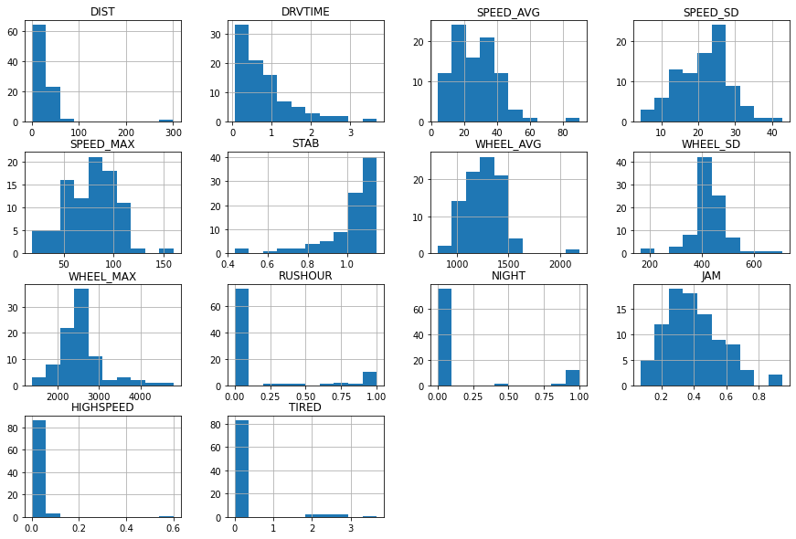

```python
# Descriptive statistics
df2_car2.hist(figsize=(15,10))
df2_car2.describe()
```

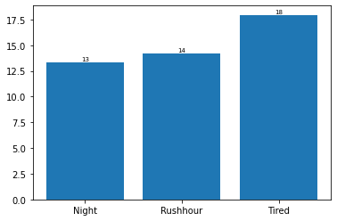

```python
# # Fatigue driving time, morning and evening peak hours, and late night travel time ratio

df2_car2.sum()
ylabel = [df2_car2.sum()["NIGHT"],df2_car2.sum()["RUSHOUR"],df2_car2.sum()["TIRED"]]
xlabel = ["Night" , "Rushhour" , "Tired"]
plt.bar(xlabel , ylabel)

for a,b in zip(xlabel,ylabel):
    plt.text(a, b+0.05, '%.0f' % b, ha='center', va= 'bottom',fontsize=7)

plt.show()
```

## Data Analysis of Car 3

|  | DIST | DRVTIME | SPEED_AVG | SPEED_SD | SPEED_MAX | STAB | WHEEL_AVG | WHEEL_SD | WHEEL_MAX | RUSHOUR | NIGHT | JAM | HIGHSPEED | TIRED |
| --- | --- | --- | --- | --- | --- | --- | --- | --- | --- | --- | --- | --- | --- | --- |
| count | 47.000000 | 47.000000 | 47.000000 | 47.000000 | 47.000000 | 47.000000 | 47.000000 | 47.000000 | 47.000000 | 47.000000 | 47.000000 | 47.000000 | 47.000000 | 47.000000 |
| mean | 17.767021 | 0.563717 | 33.153858 | 23.641058 | 80.851064 | 1.011844 | 1054.748391 | 219.017758 | 1663.000000 | 0.376147 | 0.039835 | 0.336342 | 0.024730 | 0.051099 |
| std | 15.412200 | 0.350808 | 14.061302 | 6.418384 | 21.447589 | 0.054069 | 95.757763 | 46.996182 | 217.285727 | 0.480970 | 0.191461 | 0.184339 | 0.035204 | 0.350319 |
| min | 0.050000 | 0.065556 | 7.828571 | 9.595129 | 32.000000 | 0.871155 | 877.896552 | 84.163678 | 1119.000000 | 0.000000 | 0.000000 | 0.042289 | 0.000000 | 0.000000 |
| 25% | 5.000000 | 0.367501 | 22.293871 | 19.274969 | 61.000000 | 0.987632 | 989.717026 | 189.858671 | 1502.000000 | 0.000000 | 0.000000 | 0.208975 | 0.000000 | 0.000000 |
| 50% | 22.000000 | 0.558055 | 36.800830 | 23.275753 | 92.000000 | 1.027799 | 1068.655602 | 222.275246 | 1681.000000 | 0.000000 | 0.000000 | 0.273782 | 0.004376 | 0.000000 |
| 75% | 26.000000 | 0.672502 | 45.012671 | 29.750537 | 99.500000 | 1.050661 | 1133.543887 | 250.350009 | 1768.500000 | 1.000000 | 0.000000 | 0.425217 | 0.042327 | 0.000000 |
| max | 81.000000 | 2.401666 | 55.746741 | 33.939112 | 113.000000 | 1.080883 | 1234.338920 | 318.497851 | 2370.000000 | 1.000000 | 1.000000 | 0.771429 | 0.134078 | 2.401666 |

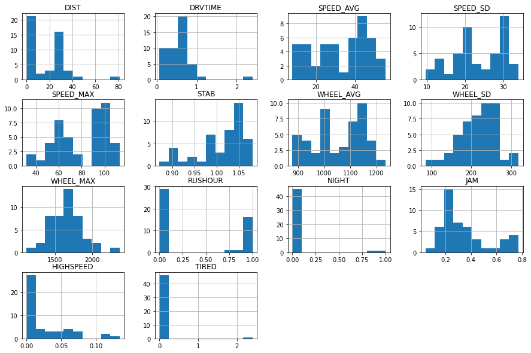

```python
# Descriptive statistics
df2_car3.hist(figsize=(15,10))
df2_car3.describe()
```

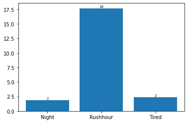

```python
## Fatigue driving time, morning and evening peak hours, and late night travel time ratio

df2_car3.sum()
ylabel = [df2_car3.sum()["NIGHT"],df2_car3.sum()["RUSHOUR"],df2_car3.sum()["TIRED"]]
xlabel = ["Night" , "Rushhour" , "Tired"]
plt.bar(xlabel , ylabel)

for a,b in zip(xlabel,ylabel):
    plt.text(a, b+0.05, '%.0f' % b, ha='center', va= 'bottom',fontsize=7)

plt.show()
```

## Data Analysis of Car 4

|  | DIST | DRVTIME | SPEED_AVG | SPEED_SD | SPEED_MAX | STAB | WHEEL_AVG | WHEEL_SD | WHEEL_MAX | RUSHOUR | NIGHT | JAM | HIGHSPEED | TIRED |
| --- | --- | --- | --- | --- | --- | --- | --- | --- | --- | --- | --- | --- | --- | --- |
| count | 163.000000 | 163.000000 | 163.000000 | 163.000000 | 163.000000 | 163.000000 | 163.000000 | 163.000000 | 163.000000 | 163.000000 | 163.000000 | 163.000000 | 163.000000 | 163.000000 |
| mean | 11.909939 | 0.474765 | 27.746091 | 21.535173 | 72.503067 | 1.038488 | 1392.896612 | 498.624896 | 2401.920245 | 0.308302 | 0.080073 | 0.356298 | 0.006713 | 0.035000 |
| std | 11.351085 | 0.403640 | 11.172912 | 6.107870 | 19.984678 | 0.145447 | 210.858963 | 68.328522 | 265.797727 | 0.443231 | 0.265415 | 0.162448 | 0.026073 | 0.315042 |
| min | 0.040000 | 0.051667 | 2.111111 | 2.088327 | 6.000000 | 0.401831 | 756.222222 | 109.300935 | 982.000000 | 0.000000 | 0.000000 | 0.024390 | 0.000000 | 0.000000 |
| 25% | 4.000000 | 0.243750 | 19.289124 | 17.483157 | 61.000000 | 0.969937 | 1225.315979 | 461.400982 | 2309.500000 | 0.000000 | 0.000000 | 0.246134 | 0.000000 | 0.000000 |
| 50% | 9.000000 | 0.372223 | 28.577540 | 22.281861 | 76.000000 | 1.083322 | 1394.832090 | 509.250878 | 2397.000000 | 0.000000 | 0.000000 | 0.320628 | 0.000000 | 0.000000 |
| 75% | 17.000000 | 0.556667 | 35.668844 | 25.597505 | 85.500000 | 1.150030 | 1555.218878 | 541.285757 | 2519.500000 | 0.991768 | 0.000000 | 0.447288 | 0.000000 | 0.000000 |
| max | 79.000000 | 2.902222 | 52.688776 | 34.033714 | 114.000000 | 1.197489 | 1862.051020 | 674.089493 | 3675.000000 | 1.000000 | 1.000000 | 1.000000 | 0.187075 | 2.902222 |

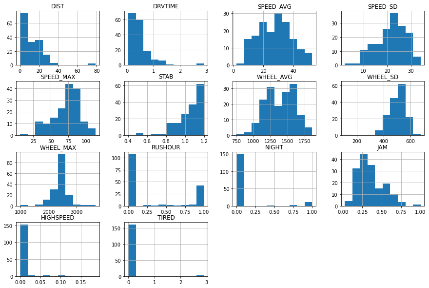

```python
# Descriptive statistics
df2_car4.hist(figsize=(15,10))
df2_car4.describe()
```

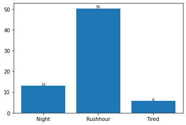

```python
# Fatigue driving time, morning and evening peak hours, and late night travel time ratio

df2_car4.sum()
ylabel = [df2_car4.sum()["NIGHT"],df2_car4.sum()["RUSHOUR"],df2_car4.sum()["TIRED"]]
xlabel = ["Night" , "Rushhour" , "Tired"]
plt.bar(xlabel , ylabel)

for a,b in zip(xlabel,ylabel):
    plt.text(a, b+0.05, '%.0f' % b, ha='center', va= 'bottom',fontsize=7)

plt.show()
```

## Data Analysis of Car 5

|  | DIST | DRVTIME | SPEED_AVG | SPEED_SD | SPEED_MAX | STAB | WHEEL_AVG | WHEEL_SD | WHEEL_MAX | RUSHOUR | NIGHT | JAM | HIGHSPEED | TIRED |
| --- | --- | --- | --- | --- | --- | --- | --- | --- | --- | --- | --- | --- | --- | --- |
| count | 80.000000 | 80.000000 | 80.000000 | 80.000000 | 80.000000 | 80.000000 | 80.000000 | 80.000000 | 80.00000 | 80.000000 | 80.000000 | 80.000000 | 80.000000 | 80.000000 |
| mean | 6.256500 | 0.542118 | 27.192527 | 20.165014 | 68.500000 | 1.059351 | 1301.038080 | 362.529250 | 2078.31250 | 0.272891 | 0.027987 | 0.395973 | 0.031800 | 0.145184 |
| std | 11.644296 | 0.606372 | 15.394277 | 8.445705 | 28.441813 | 0.215324 | 193.133323 | 70.111393 | 311.44545 | 0.430872 | 0.157749 | 0.213933 | 0.093466 | 0.568567 |
| min | 0.050000 | 0.061668 | 2.142857 | 2.878492 | 11.000000 | 0.164684 | 899.857143 | 94.176477 | 1218.00000 | 0.000000 | 0.000000 | 0.083333 | 0.000000 | 0.000000 |
| 25% | 0.147500 | 0.146528 | 16.294034 | 14.583565 | 49.000000 | 0.978966 | 1138.056782 | 340.206475 | 1930.00000 | 0.000000 | 0.000000 | 0.220140 | 0.000000 | 0.000000 |
| 50% | 1.500000 | 0.321667 | 23.837033 | 19.289211 | 65.500000 | 1.096713 | 1309.486075 | 376.693314 | 2098.00000 | 0.000000 | 0.000000 | 0.350573 | 0.000000 | 0.000000 |
| 75% | 4.000000 | 0.625834 | 38.407165 | 23.154567 | 80.500000 | 1.200267 | 1465.719994 | 402.766998 | 2212.50000 | 0.757265 | 0.000000 | 0.546127 | 0.000000 | 0.000000 |
| max | 49.000000 | 2.678611 | 72.447639 | 43.583145 | 135.000000 | 1.383501 | 1682.642710 | 504.830169 | 2861.00000 | 1.000000 | 1.000000 | 1.000000 | 0.457906 | 2.678611 |

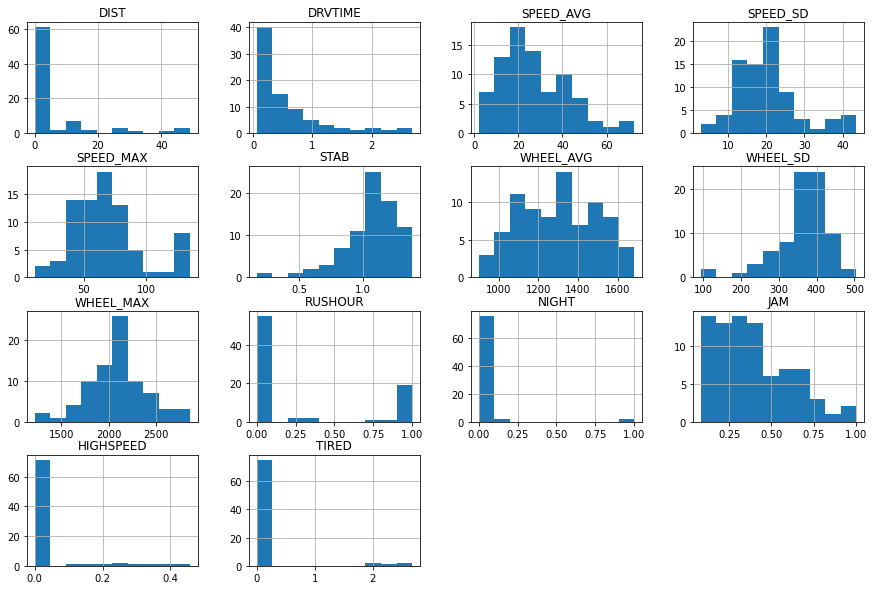

```python
# Descriptive statistics
df2_car5.hist(figsize=(15,10))
df2_car5.describe()
```

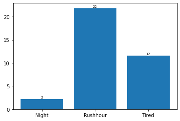

```python
# # Fatigue driving time, morning and evening peak hours, and late night travel time ratio

df2_car5.sum()
ylabel = [df2_car5.sum()["NIGHT"],df2_car5.sum()["RUSHOUR"],df2_car5.sum()["TIRED"]]
xlabel = ["Night" , "Rushhour" , "Tired"]
plt.bar(xlabel , ylabel)

for a,b in zip(xlabel,ylabel):
    plt.text(a, b+0.05, '%.0f' % b, ha='center', va= 'bottom',fontsize=7)

plt.show()
```

## Data Analysis of Car 6

|  | DIST | DRVTIME | SPEED_AVG | SPEED_SD | SPEED_MAX | STAB | WHEEL_AVG | WHEEL_SD | WHEEL_MAX | RUSHOUR | NIGHT | JAM | HIGHSPEED | TIRED |
| --- | --- | --- | --- | --- | --- | --- | --- | --- | --- | --- | --- | --- | --- | --- |
| count | 155.000000 | 155.000000 | 155.000000 | 155.000000 | 155.000000 | 155.000000 | 155.000000 | 155.000000 | 155.000000 | 155.000000 | 155.000000 | 155.000000 | 155.000000 | 155.000000 |
| mean | 7.690968 | 0.389115 | 20.383056 | 15.721657 | 61.458065 | 1.019560 | 1213.827490 | 336.997729 | 2298.090323 | 0.329782 | 0.033067 | 0.403188 | 0.007061 | 0.056500 |
| std | 17.872770 | 0.437168 | 10.272473 | 6.623799 | 27.762265 | 0.253519 | 148.790416 | 109.695350 | 775.020422 | 0.458165 | 0.177395 | 0.183739 | 0.035958 | 0.348976 |
| min | 0.040000 | 0.052222 | 1.054054 | 4.149605 | 19.000000 | 0.024315 | 852.108108 | 148.341411 | 1364.000000 | 0.000000 | 0.000000 | 0.072072 | 0.000000 | 0.000000 |
| 25% | 1.000000 | 0.138889 | 13.524680 | 11.244763 | 43.000000 | 0.851760 | 1101.607335 | 277.639621 | 1805.500000 | 0.000000 | 0.000000 | 0.261485 | 0.000000 | 0.000000 |
| 50% | 2.000000 | 0.237221 | 18.469697 | 14.566379 | 58.000000 | 1.053459 | 1204.119171 | 311.688705 | 1965.000000 | 0.000000 | 0.000000 | 0.385542 | 0.000000 | 0.000000 |
| 75% | 4.000000 | 0.417084 | 24.950878 | 18.635645 | 69.500000 | 1.226839 | 1313.309259 | 351.032166 | 2508.000000 | 1.000000 | 0.000000 | 0.527309 | 0.000000 | 0.000000 |
| max | 134.000000 | 2.330278 | 62.298143 | 47.444204 | 177.000000 | 1.473426 | 1654.081134 | 890.778758 | 5411.000000 | 1.000000 | 1.000000 | 0.972973 | 0.356794 | 2.330278 |

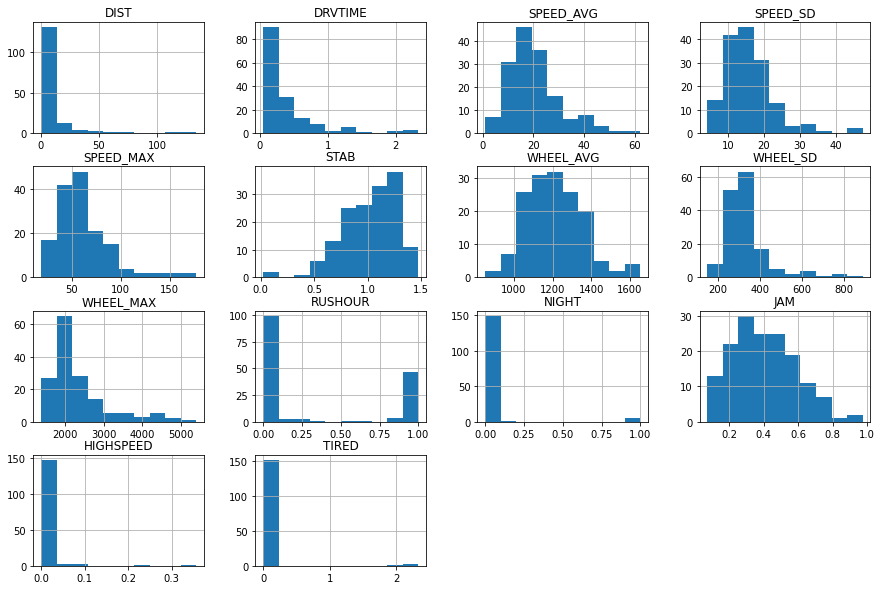

```python
# Descriptive statistics
df2_car6.hist(figsize=(15,10))
df2_car6.describe()
```

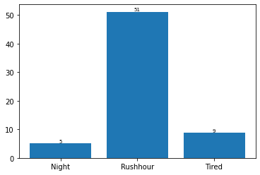

```python
# Fatigue driving time, morning and evening peak hours, and late night travel time ratio

df2_car6.sum()
ylabel = [df2_car6.sum()["NIGHT"],df2_car6.sum()["RUSHOUR"],df2_car6.sum()["TIRED"]]
xlabel = ["Night" , "Rushhour" , "Tired"]
plt.bar(xlabel , ylabel)

for a,b in zip(xlabel,ylabel):
    plt.text(a, b+0.05, '%.0f' % b, ha='center', va= 'bottom',fontsize=7)

plt.show()
```

## Data Analysis of Car 7

|  | DIST | DRVTIME | SPEED_AVG | SPEED_SD | SPEED_MAX | STAB | WHEEL_AVG | WHEEL_SD | WHEEL_MAX | RUSHOUR | NIGHT | JAM | HIGHSPEED | TIRED |
| --- | --- | --- | --- | --- | --- | --- | --- | --- | --- | --- | --- | --- | --- | --- |
| count | 88.000000 | 88.000000 | 88.000000 | 88.000000 | 88.000000 | 88.000000 | 88.000000 | 88.000000 | 88.000000 | 88.000000 | 88.000000 | 88.000000 | 88.000000 | 88.000000 |
| mean | 6.012386 | 0.217295 | 17.407247 | 10.756584 | 40.409091 | 1.011680 | 1068.375952 | 275.354405 | 1708.977273 | 0.492583 | 0.011364 | 0.400972 | 0.011264 | 0.066111 |
| std | 31.780175 | 0.430685 | 9.763122 | 3.842533 | 14.000522 | 0.182859 | 218.632373 | 102.705455 | 384.408696 | 0.497544 | 0.106600 | 0.164127 | 0.075564 | 0.436392 |
| min | 0.040000 | 0.050556 | 7.735294 | 4.489242 | 15.000000 | 0.313260 | 828.058824 | 100.317312 | 1168.000000 | 0.000000 | 0.000000 | 0.060174 | 0.000000 | 0.000000 |
| 25% | 0.277500 | 0.070139 | 14.221328 | 8.929133 | 34.000000 | 0.931829 | 993.721460 | 218.035112 | 1468.000000 | 0.000000 | 0.000000 | 0.294668 | 0.000000 | 0.000000 |
| 50% | 1.000000 | 0.108888 | 16.193865 | 10.414513 | 39.000000 | 1.009871 | 1035.499023 | 259.260296 | 1637.500000 | 0.232237 | 0.000000 | 0.383641 | 0.000000 | 0.000000 |
| 75% | 1.000000 | 0.190834 | 18.726522 | 12.080643 | 43.250000 | 1.107327 | 1082.763821 | 310.137767 | 1798.500000 | 1.000000 | 0.000000 | 0.478414 | 0.000000 | 0.000000 |
| max | 214.000000 | 3.030278 | 79.487593 | 31.784196 | 117.000000 | 1.464606 | 2462.293424 | 802.598392 | 3494.000000 | 1.000000 | 1.000000 | 0.852941 | 0.586849 | 3.030278 |

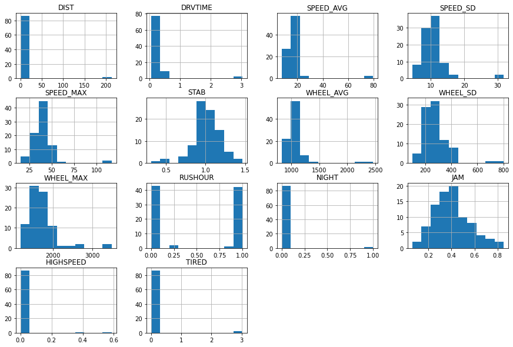

```python
# Descriptive statistics
df2_car7.hist(figsize=(15,10))
df2_car7.describe()
```

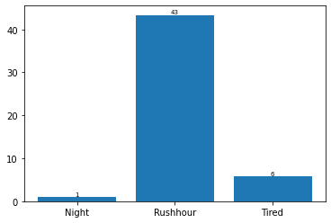

```python
# # Fatigue driving time, morning and evening peak hours, and late night travel time ratio

df2_car7.sum()
ylabel = [df2_car7.sum()["NIGHT"],df2_car7.sum()["RUSHOUR"],df2_car7.sum()["TIRED"]]
xlabel = ["Night" , "Rushhour" , "Tired"]
plt.bar(xlabel , ylabel)

for a,b in zip(xlabel,ylabel):
    plt.text(a, b+0.05, '%.0f' % b, ha='center', va= 'bottom',fontsize=7)

plt.show()
```

## Data Analysis of Car 8

|  | DIST | DRVTIME | SPEED_AVG | SPEED_SD | SPEED_MAX | STAB | WHEEL_AVG | WHEEL_SD | WHEEL_MAX | RUSHOUR | NIGHT | JAM | HIGHSPEED | TIRED |
| --- | --- | --- | --- | --- | --- | --- | --- | --- | --- | --- | --- | --- | --- | --- |
| count | 68.000000 | 68.000000 | 68.000000 | 68.000000 | 68.000000 | 68.000000 | 68.000000 | 68.000000 | 68.000000 | 68.000000 | 68.0 | 68.000000 | 68.000000 | 68.000000 |
| mean | 11.673088 | 0.473546 | 19.395128 | 14.954643 | 51.279412 | 1.021069 | 1147.886593 | 396.422393 | 2136.426471 | 0.631199 | 0.0 | 0.465911 | 0.017457 | 0.152990 |
| std | 27.687882 | 0.619766 | 11.451405 | 6.692418 | 21.252459 | 0.162417 | 199.802439 | 99.155758 | 323.807955 | 0.470825 | 0.0 | 0.171311 | 0.073757 | 0.621625 |
| min | 0.050000 | 0.060278 | 5.750617 | 7.118036 | 27.000000 | 0.559825 | 894.340741 | 271.335316 | 1607.000000 | 0.000000 | 0.0 | 0.104372 | 0.000000 | 0.000000 |
| 25% | 2.000000 | 0.168612 | 12.981203 | 10.912880 | 41.500000 | 0.941148 | 1035.464031 | 334.738295 | 1937.500000 | 0.000000 | 0.0 | 0.329710 | 0.000000 | 0.000000 |
| 50% | 3.000000 | 0.237500 | 16.951016 | 13.101936 | 45.000000 | 0.993863 | 1112.407721 | 375.150208 | 2046.000000 | 1.000000 | 0.0 | 0.463732 | 0.000000 | 0.000000 |
| 75% | 4.250000 | 0.477778 | 21.341538 | 14.983599 | 49.500000 | 1.086488 | 1200.243879 | 409.431793 | 2249.250000 | 1.000000 | 0.0 | 0.575545 | 0.000000 | 0.000000 |
| max | 128.000000 | 3.135554 | 73.125529 | 36.485503 | 113.000000 | 1.364772 | 2126.083216 | 740.382493 | 2994.000000 | 1.000000 | 0.0 | 0.837037 | 0.513399 | 3.135554 |

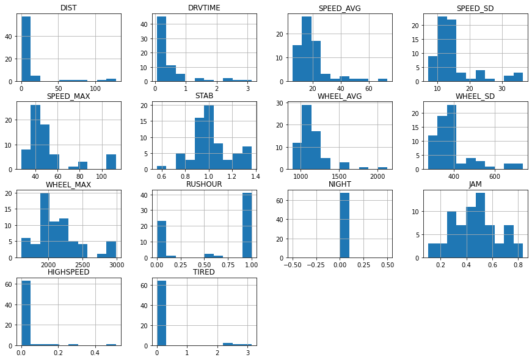

```python
# Descriptive statistics
df2_car8.hist(figsize=(15,10))
df2_car8.describe()
```

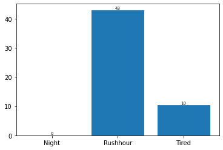

```python
# # Fatigue driving time, morning and evening peak hours, and late night travel time ratio

df2_car8.sum()
ylabel = [df2_car8.sum()["NIGHT"],df2_car8.sum()["RUSHOUR"],df2_car8.sum()["TIRED"]]
xlabel = ["Night" , "Rushhour" , "Tired"]
plt.bar(xlabel , ylabel)

for a,b in zip(xlabel,ylabel):
    plt.text(a, b+0.05, '%.0f' % b, ha='center', va= 'bottom',fontsize=7)

plt.show()
```